# Lab 5 : Data wrangling and graphing COVID-19 reporting data (Part 2)

Jarrod Daniels

9/21/2020

## Joining tables

```r
library(tidyverse)
Confirmed_State_3_13 <-   read_csv(url("https://raw.githubusercontent.com/CSSEGISandData/COVID-19/master/csse_covid_19_data/csse_covid_19_daily_reports/03-13-2020.csv")) %>%
  rename(Country_Region = "Country/Region", Province_State = "Province/State") %>%
  filter (Country_Region == "US") %>%
  group_by(Province_State, Country_Region) %>%
  summarise(Confirmed = sum(Confirmed))
str(Confirmed_State_3_13)
```

```
## Classes 'grouped_df', 'tbl_df', 'tbl' and 'data.frame':  53 obs. of  3 variables:
##  $ Province_State: chr  "Alabama" "Alaska" "Arizona" "Arkansas" ...
##  $ Country_Region: chr  "US" "US" "US" "US" ...
##  $ Confirmed     : num  5 1 9 6 282 49 11 4 46 10 ...
##  - attr(*, "spec")=
##   .. cols(
##   ..   `Province/State` = col_character(),
##   ..   `Country/Region` = col_character(),
##   ..   `Last Update` = col_datetime(format = ""),
##   ..   Confirmed = col_double(),
##   ..   Deaths = col_double(),
##   ..   Recovered = col_double(),
##   ..   Latitude = col_double(),
##   ..   Longitude = col_double()
##   .. )
##  - attr(*, "groups")=Classes 'tbl_df', 'tbl' and 'data.frame':   53 obs. of  2 variables:
##   ..$ Province_State: chr  "Alabama" "Alaska" "Arizona" "Arkansas" ...
##   ..$ .rows         :List of 53
##   .. ..$ : int 1
##   .. ..$ : int 2
##   .. ..$ : int 3
##   .. ..$ : int 4
##   .. ..$ : int 5
##   .. ..$ : int 6
##   .. ..$ : int 7
##   .. ..$ : int 8
##   .. ..$ : int 9
##   .. ..$ : int 10
##   .. ..$ : int 11
##   .. ..$ : int 12
##   .. ..$ : int 13
##   .. ..$ : int 14
##   .. ..$ : int 15
##   .. ..$ : int 16
##   .. ..$ : int 17
##   .. ..$ : int 18
##   .. ..$ : int 19
##   .. ..$ : int 20
##   .. ..$ : int 21
##   .. ..$ : int 22
```

[output cut: 17 more lines]

```
##   .. ..$ : int 40
##   .. ..$ : int 41
##   .. ..$ : int 42
##   .. ..$ : int 43
##   .. ..$ : int 44
##   .. ..$ : int 45
##   .. ..$ : int 46
##   .. ..$ : int 47
##   .. ..$ : int 48
##   .. ..$ : int 49
##   .. ..$ : int 50
##   .. ..$ : int 51
##   .. ..$ : int 52
##   .. ..$ : int 53
##   ..- attr(*, ".drop")= logi TRUE
```

```r
Confirmed_State_9_13 <-   read_csv(url("https://raw.githubusercontent.com/CSSEGISandData/COVID-19/master/csse_covid_19_data/csse_covid_19_daily_reports/09-13-2020.csv")) %>%
  filter (Country_Region == "US") %>%
  group_by(Province_State, Country_Region) %>%
  summarise(Confirmed = sum(Confirmed))
str(Confirmed_State_9_13)
```

```
## Classes 'grouped_df', 'tbl_df', 'tbl' and 'data.frame':  58 obs. of  3 variables:
##  $ Province_State: chr  "Alabama" "Alaska" "Arizona" "Arkansas" ...
##  $ Country_Region: chr  "US" "US" "US" "US" ...
##  $ Confirmed     : num  138755 6268 208512 70219 761728 ...
##  - attr(*, "spec")=
##   .. cols(
##   ..   FIPS = col_double(),
##   ..   Admin2 = col_character(),
##   ..   Province_State = col_character(),
##   ..   Country_Region = col_character(),
##   ..   Last_Update = col_datetime(format = ""),
##   ..   Lat = col_double(),
##   ..   Long_ = col_double(),
##   ..   Confirmed = col_double(),
##   ..   Deaths = col_double(),
##   ..   Recovered = col_double(),
##   ..   Active = col_double(),
##   ..   Combined_Key = col_character(),
##   ..   Incidence_Rate = col_double(),
##   ..   `Case-Fatality_Ratio` = col_double()
##   .. )
##  - attr(*, "groups")=Classes 'tbl_df', 'tbl' and 'data.frame':   58 obs. of  2 variables:
##   ..$ Province_State: chr  "Alabama" "Alaska" "Arizona" "Arkansas" ...
##   ..$ .rows         :List of 58
##   .. ..$ : int 1
##   .. ..$ : int 2
##   .. ..$ : int 3
##   .. ..$ : int 4
##   .. ..$ : int 5
##   .. ..$ : int 6
##   .. ..$ : int 7
##   .. ..$ : int 8
##   .. ..$ : int 9
##   .. ..$ : int 10
##   .. ..$ : int 11
##   .. ..$ : int 12
##   .. ..$ : int 13
##   .. ..$ : int 14
##   .. ..$ : int 15
##   .. ..$ : int 16
```

[output cut: 28 more lines]

```
##   .. ..$ : int 45
##   .. ..$ : int 46
##   .. ..$ : int 47
##   .. ..$ : int 48
##   .. ..$ : int 49
##   .. ..$ : int 50
##   .. ..$ : int 51
##   .. ..$ : int 52
##   .. ..$ : int 53
##   .. ..$ : int 54
##   .. ..$ : int 55
##   .. ..$ : int 56
##   .. ..$ : int 57
##   .. ..$ : int 58
##   ..- attr(*, ".drop")= logi TRUE
```

Notice from the above `str’ calls that there are 53 states in the table on 3/13/2020 and 58 states in the table on 9/13/2020

```r
setdiff(Confirmed_State_9_13$Province_State, Confirmed_State_3_13$Province_State)
```

```
## [1] "Guam"                     "Northern Mariana Islands"
## [3] "Puerto Rico"              "Recovered"
## [5] "Virgin Islands"
```

There are 4 US territories a field you may have notice last week “Recovered”. We don’t need the “Recovered” row so let’s filter it from the data set.

```r
Confirmed_State_9_13 <- Confirmed_State_9_13 %>%
  filter(Province_State != "Recovered")
```

```r
Confirmed_State_3_13_9_13_joined <- full_join(Confirmed_State_3_13,
      Confirmed_State_9_13, by = c("Province_State"))
head(Confirmed_State_3_13_9_13_joined)
```

```
## # A tibble: 6 x 5
## # Groups:   Province_State [6]
##   Province_State Country_Region.x Confirmed.x Country_Region.y Confirmed.y
##   <chr>          <chr>                  <dbl> <chr>                  <dbl>
## 1 Alabama        US                         5 US                    138755
## 2 Alaska         US                         1 US                      6268
## 3 Arizona        US                         9 US                    208512
## 4 Arkansas       US                         6 US                     70219
## 5 California     US                       282 US                    761728
## 6 Colorado       US                        49 US                     61293
```

This results in the values for Guam, Northern Mariana Islands, Puerto Rico and the Virgin Islands being NA for 3/13

```r
tail(Confirmed_State_3_13_9_13_joined, 5)
```

```
## # A tibble: 5 x 5
## # Groups:   Province_State [5]
##   Province_State       Country_Region.x Confirmed.x Country_Region.y Confirmed.y
##   <chr>                <chr>                  <dbl> <chr>                  <dbl>
## 1 Wyoming              US                         1 US                      4346
## 2 Guam                 <NA>                      NA US                      1863
## 3 Northern Mariana Is~ <NA>                      NA US                        60
## 4 Puerto Rico          <NA>                      NA US                     37380
## 5 Virgin Islands       <NA>                      NA US                      1220
```

Or

```r
which(is.na(Confirmed_State_3_13_9_13_joined))
```

```
## [1] 111 112 113 114 168 169 170 171
```

Let’s turn the NAs into 0. Also notice that we know have columns Confirmed.x Country_Region.x, Confirmed.y Country_Region.y. So let’s rename the Confirmed columns and delete the Country_Region columns

```r
Confirmed_State_3_13_9_13_joined <- full_join(Confirmed_State_3_13,
      Confirmed_State_9_13, by = c("Province_State")) %>%
      rename(Confirmed_3_13_2020 = "Confirmed.x", Confirmed_9_13_2020 = "Confirmed.y") %>%
      select(-Country_Region.x, -Country_Region.y) %>%
      replace_na(list(Confirmed_3_13_2020 = 0))
head(Confirmed_State_3_13_9_13_joined)
```

```
## # A tibble: 6 x 3
## # Groups:   Province_State [6]
##   Province_State Confirmed_3_13_2020 Confirmed_9_13_2020
##   <chr>                        <dbl>               <dbl>
## 1 Alabama                          5              138755
## 2 Alaska                           1                6268
## 3 Arizona                          9              208512
## 4 Arkansas                         6               70219
## 5 California                     282              761728
## 6 Colorado                        49               61293
```

```r
which(is.na(Confirmed_State_3_13_9_13_joined))
```

```
## integer(0)
```

## Switching between wide and long table formats

gather and spead were used in the Data Carpentries tutorial to switch between wide and long table formats. They work fine, but are being replaced by the newer functions pivot_longer and pivot_wider. which we will use below. See the pivot vignette for other examples

```r
Confirmed_State_3_13_9_13_joined_long <- Confirmed_State_3_13_9_13_joined %>%
              pivot_longer(-c(Province_State),
                            names_to = "Date", values_to = "Confirmed")
```

Now we can use this table in plot that shows the confirmed cases for both dates.

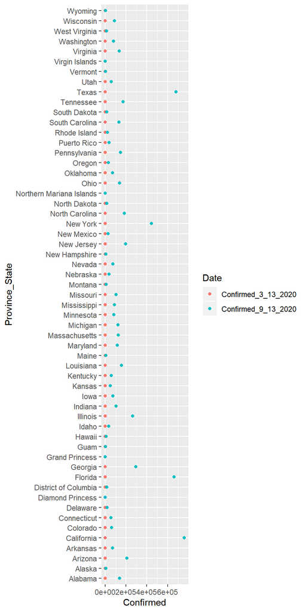

```r
# to adjust figure size {r, fig.width = 5, fig.height = 10}
ggplot(Confirmed_State_3_13_9_13_joined_long, aes(x = Confirmed,  y = Province_State))  +
    geom_point(aes(color = Date))
```

## Working with time series data

# Data Wranling

Start by loading the most recent times series data for confirmed cases

```r
time_series_confirmed <- read_csv(url("https://raw.githubusercontent.com/CSSEGISandData/COVID-19/master/csse_covid_19_data/csse_covid_19_time_series/time_series_covid19_confirmed_global.csv")) %>%
  rename(Province_State = "Province/State", Country_Region = "Country/Region")
```

Note that in some cases it is best to have the date on your computer and then load the file into R.

```r
 download.file(url="https://raw.githubusercontent.com/CSSEGISandData/COVID-19/master/csse_covid_19_data/csse_covid_19_time_series/time_series_covid19_confirmed_global.csv",
               destfile = "data/time_series_covid19_confirmed_global.csv")
```

```r
time_series_confirmed <- read_csv("data/time_series_covid19_confirmed_global.csv")%>%
  rename(Province_State = "Province/State", Country_Region = "Country/Region")
```

Check the table properties to make sure the data imported as we expected

```r
head(time_series_confirmed)
```

```
## # A tibble: 6 x 247
##   Province_State Country_Region   Lat   Long `1/22/20` `1/23/20` `1/24/20`
##   <chr>          <chr>          <dbl>  <dbl>     <dbl>     <dbl>     <dbl>
## 1 <NA>           Afghanistan     33.9  67.7          0         0         0
## 2 <NA>           Albania         41.2  20.2          0         0         0
## 3 <NA>           Algeria         28.0   1.66         0         0         0
## 4 <NA>           Andorra         42.5   1.52         0         0         0
## 5 <NA>           Angola         -11.2  17.9          0         0         0
## 6 <NA>           Antigua and B~  17.1 -61.8          0         0         0
## # ... with 240 more variables: `1/25/20` <dbl>, `1/26/20` <dbl>,
## #   `1/27/20` <dbl>, `1/28/20` <dbl>, `1/29/20` <dbl>, `1/30/20` <dbl>,
## #   `1/31/20` <dbl>, `2/1/20` <dbl>, `2/2/20` <dbl>, `2/3/20` <dbl>,
## #   `2/4/20` <dbl>, `2/5/20` <dbl>, `2/6/20` <dbl>, `2/7/20` <dbl>,
## #   `2/8/20` <dbl>, `2/9/20` <dbl>, `2/10/20` <dbl>, `2/11/20` <dbl>,
## #   `2/12/20` <dbl>, `2/13/20` <dbl>, `2/14/20` <dbl>, `2/15/20` <dbl>,
## #   `2/16/20` <dbl>, `2/17/20` <dbl>, `2/18/20` <dbl>, `2/19/20` <dbl>,
## #   `2/20/20` <dbl>, `2/21/20` <dbl>, `2/22/20` <dbl>, `2/23/20` <dbl>,
## #   `2/24/20` <dbl>, `2/25/20` <dbl>, `2/26/20` <dbl>, `2/27/20` <dbl>,
## #   `2/28/20` <dbl>, `2/29/20` <dbl>, `3/1/20` <dbl>, `3/2/20` <dbl>,
## #   `3/3/20` <dbl>, `3/4/20` <dbl>, `3/5/20` <dbl>, `3/6/20` <dbl>,
## #   `3/7/20` <dbl>, `3/8/20` <dbl>, `3/9/20` <dbl>, `3/10/20` <dbl>,
## #   `3/11/20` <dbl>, `3/12/20` <dbl>, `3/13/20` <dbl>, `3/14/20` <dbl>,
## #   `3/15/20` <dbl>, `3/16/20` <dbl>, `3/17/20` <dbl>, `3/18/20` <dbl>,
## #   `3/19/20` <dbl>, `3/20/20` <dbl>, `3/21/20` <dbl>, `3/22/20` <dbl>,
## #   `3/23/20` <dbl>, `3/24/20` <dbl>, `3/25/20` <dbl>, `3/26/20` <dbl>,
## #   `3/27/20` <dbl>, `3/28/20` <dbl>, `3/29/20` <dbl>, `3/30/20` <dbl>,
## #   `3/31/20` <dbl>, `4/1/20` <dbl>, `4/2/20` <dbl>, `4/3/20` <dbl>,
## #   `4/4/20` <dbl>, `4/5/20` <dbl>, `4/6/20` <dbl>, `4/7/20` <dbl>,
## #   `4/8/20` <dbl>, `4/9/20` <dbl>, `4/10/20` <dbl>, `4/11/20` <dbl>,
## #   `4/12/20` <dbl>, `4/13/20` <dbl>, `4/14/20` <dbl>, `4/15/20` <dbl>,
## #   `4/16/20` <dbl>, `4/17/20` <dbl>, `4/18/20` <dbl>, `4/19/20` <dbl>,
## #   `4/20/20` <dbl>, `4/21/20` <dbl>, `4/22/20` <dbl>, `4/23/20` <dbl>,
## #   `4/24/20` <dbl>, `4/25/20` <dbl>, `4/26/20` <dbl>, `4/27/20` <dbl>,
## #   `4/28/20` <dbl>, `4/29/20` <dbl>, `4/30/20` <dbl>, `5/1/20` <dbl>,
## #   `5/2/20` <dbl>, `5/3/20` <dbl>, ...
```

As noted above this data is in wide format. To convert to long format

```r
time_series_confirmed_long <- time_series_confirmed %>%
               pivot_longer(-c(Province_State, Country_Region, Lat, Long),
                            names_to = "Date", values_to = "Confirmed")
```

Let’s look at the format of the data frame (tibble) now

```r
head(time_series_confirmed_long)
```

```
## # A tibble: 6 x 6
##   Province_State Country_Region   Lat  Long Date    Confirmed
##   <chr>          <chr>          <dbl> <dbl> <chr>       <dbl>
## 1 <NA>           Afghanistan     33.9  67.7 1/22/20         0
## 2 <NA>           Afghanistan     33.9  67.7 1/23/20         0
## 3 <NA>           Afghanistan     33.9  67.7 1/24/20         0
## 4 <NA>           Afghanistan     33.9  67.7 1/25/20         0
## 5 <NA>           Afghanistan     33.9  67.7 1/26/20         0
## 6 <NA>           Afghanistan     33.9  67.7 1/27/20         0
```

It would be convenient to have the confirmed cases and deaths in the same table. We can create another table with the deaths and then join the two tables. First let’s

```r
 download.file(url="https://raw.githubusercontent.com/CSSEGISandData/COVID-19/master/csse_covid_19_data/csse_covid_19_time_series/time_series_covid19_deaths_global.csv",
               destfile = "data/time_series_covid19_deaths_global.csv")
```

```r
time_series_deaths <- read_csv("data/time_series_covid19_deaths_global.csv")%>%
  rename(Province_State = "Province/State", Country_Region = "Country/Region")
```

As noted above this data is in wide format. To convert to long format

```r
time_series_deaths_long <- time_series_deaths %>%
               pivot_longer(-c(Province_State, Country_Region, Lat, Long),
                            names_to = "Date", values_to = "Deaths")
head(time_series_deaths_long)
```

```
## # A tibble: 6 x 6
##   Province_State Country_Region   Lat  Long Date    Deaths
##   <chr>          <chr>          <dbl> <dbl> <chr>    <dbl>
## 1 <NA>           Afghanistan     33.9  67.7 1/22/20      0
## 2 <NA>           Afghanistan     33.9  67.7 1/23/20      0
## 3 <NA>           Afghanistan     33.9  67.7 1/24/20      0
## 4 <NA>           Afghanistan     33.9  67.7 1/25/20      0
## 5 <NA>           Afghanistan     33.9  67.7 1/26/20      0
## 6 <NA>           Afghanistan     33.9  67.7 1/27/20      0
```

# Joining the time series tables

To join 2 tables we need a common column in which each row is a unique name. This is often called the Key. None of the columns in this data set meet that criteria, but we can create a column to serve as our key by mergering the names for the Province_State, Country_Region and Date columns using unite

```r
time_series_confirmed_long <- time_series_confirmed_long %>%
  unite(Key, Province_State, Country_Region, Date, sep = ".", remove = FALSE)
head(time_series_confirmed_long)
```

```
## # A tibble: 6 x 7
##   Key                 Province_State Country_Region   Lat  Long Date   Confirmed
##   <chr>               <chr>          <chr>          <dbl> <dbl> <chr>      <dbl>
## 1 NA.Afghanistan.1/2~ <NA>           Afghanistan     33.9  67.7 1/22/~         0
## 2 NA.Afghanistan.1/2~ <NA>           Afghanistan     33.9  67.7 1/23/~         0
## 3 NA.Afghanistan.1/2~ <NA>           Afghanistan     33.9  67.7 1/24/~         0
## 4 NA.Afghanistan.1/2~ <NA>           Afghanistan     33.9  67.7 1/25/~         0
## 5 NA.Afghanistan.1/2~ <NA>           Afghanistan     33.9  67.7 1/26/~         0
## 6 NA.Afghanistan.1/2~ <NA>           Afghanistan     33.9  67.7 1/27/~         0
```

For the second table we can do the same and eliminate the columns that are redundant so that we just have the Key and Deaths columns

```r
time_series_deaths_long <- time_series_deaths_long %>%
  unite(Key, Province_State, Country_Region, Date, sep = ".") %>%
  select(Key, Deaths)
```

Now to join the tables. A full_join which means that the keys that are common to the tables will be joined and there will be counts for both Confirmed and Deaths. Where there are not matching values, returns NA for the one missing. select can be used to remove the key after the join since we don’t have further need for it.

```r
time_series_long_joined <- full_join(time_series_confirmed_long,
              time_series_deaths_long, by = c("Key")) %>%
              select(-Key)
head(time_series_long_joined)
```

```
## # A tibble: 6 x 7
##   Province_State Country_Region   Lat  Long Date    Confirmed Deaths
##   <chr>          <chr>          <dbl> <dbl> <chr>       <dbl>  <dbl>
## 1 <NA>           Afghanistan     33.9  67.7 1/22/20         0      0
## 2 <NA>           Afghanistan     33.9  67.7 1/23/20         0      0
## 3 <NA>           Afghanistan     33.9  67.7 1/24/20         0      0
## 4 <NA>           Afghanistan     33.9  67.7 1/25/20         0      0
## 5 <NA>           Afghanistan     33.9  67.7 1/26/20         0      0
## 6 <NA>           Afghanistan     33.9  67.7 1/27/20         0      0
```

Check to make sure neither the Cofirmed or Death counts have NA as a value (both tables have the same number of rows, but we should check to make sure)

```r
which(is.na(time_series_long_joined$Confirmed))
```

```
## integer(0)
```

```r
which(is.na(time_series_long_joined$Deaths))
```

```
## integer(0)
```

```r
library(lubridate)
time_series_long_joined$Date <- mdy(time_series_long_joined$Date)
```

Confirmed and Deaths are count data and there may be times when we want to plot both on the same graph. There are multiple ways to accomplish this and one is through creating a column using _pivot_long

```r
time_series_long_joined_counts <- time_series_long_joined %>%
  pivot_longer(-c(Province_State, Country_Region, Lat, Long, Date),
               names_to = "Report_Type", values_to = "Counts")
head(time_series_long_joined_counts)
```

```
## # A tibble: 6 x 7
##   Province_State Country_Region   Lat  Long Date       Report_Type Counts
##   <chr>          <chr>          <dbl> <dbl> <date>     <chr>        <dbl>
## 1 <NA>           Afghanistan     33.9  67.7 2020-01-22 Confirmed        0
## 2 <NA>           Afghanistan     33.9  67.7 2020-01-22 Deaths           0
## 3 <NA>           Afghanistan     33.9  67.7 2020-01-23 Confirmed        0
## 4 <NA>           Afghanistan     33.9  67.7 2020-01-23 Deaths           0
## 5 <NA>           Afghanistan     33.9  67.7 2020-01-24 Confirmed        0
## 6 <NA>           Afghanistan     33.9  67.7 2020-01-24 Deaths           0
```

# Making Graphs from the time series data

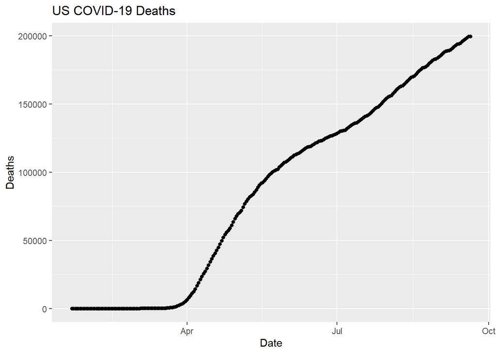

```r
time_series_long_joined %>%
  group_by(Country_Region,Date) %>%
  summarise_at(c("Confirmed", "Deaths"), sum) %>%
  filter (Country_Region == "US") %>%
    ggplot(aes(x = Date,  y = Deaths)) +
    geom_point() +
    geom_line() +
    ggtitle("US COVID-19 Deaths")
```

Let’s look at the US data in the context of a few other countries

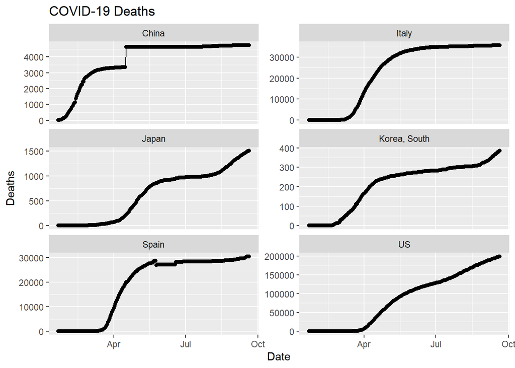

```r
time_series_long_joined %>%
  group_by(Country_Region,Date) %>%
  summarise_at(c("Confirmed", "Deaths"), sum) %>%
  filter (Country_Region %in% c("China","Japan", "Korea, South",
                                "Italy","Spain", "US")) %>%
    ggplot(aes(x = Date,  y = Deaths)) +
    geom_point() +
    geom_line() +
    ggtitle("COVID-19 Deaths") +
    facet_wrap(~Country_Region, ncol=2, scales="free_y")
```

Now several countries on the same graph

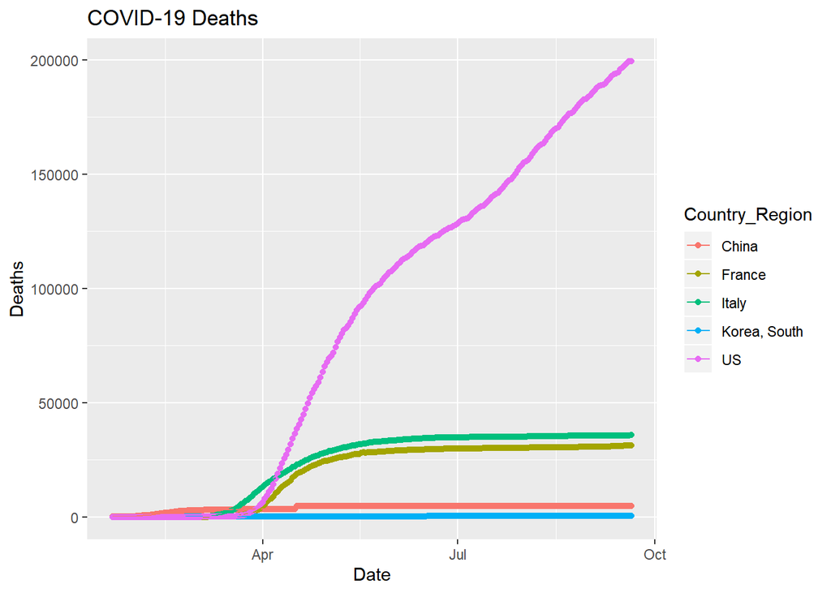

```r
time_series_long_joined %>%
    group_by(Country_Region,Date) %>%
    summarise_at(c("Confirmed", "Deaths"), sum) %>%
    filter (Country_Region %in% c("China","France","Italy",
                                "Korea, South", "US")) %>%
    ggplot(aes(x = Date,  y = Deaths, color = Country_Region)) +
    geom_point() +
    geom_line() +
    ggtitle("COVID-19 Deaths")
```

We can use the alternative data frame with column Report_Type to show Confirmed and Deaths. Because the counts for Deaths are low relative to Confirmed a log scale works best here for seeing the pattern

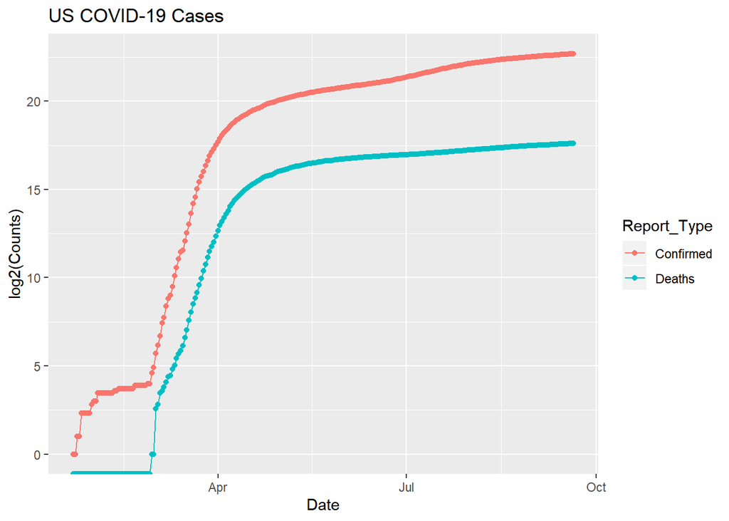

```r
time_series_long_joined_counts %>%
  group_by(Country_Region, Report_Type, Date) %>%
  summarise(Counts = sum(Counts)) %>%
  filter (Country_Region == "US") %>%
    ggplot(aes(x = Date,  y = log2(Counts), fill = Report_Type, color = Report_Type)) +
    geom_point() +
    geom_line() +
    ggtitle("US COVID-19 Cases")
```

## Exercises

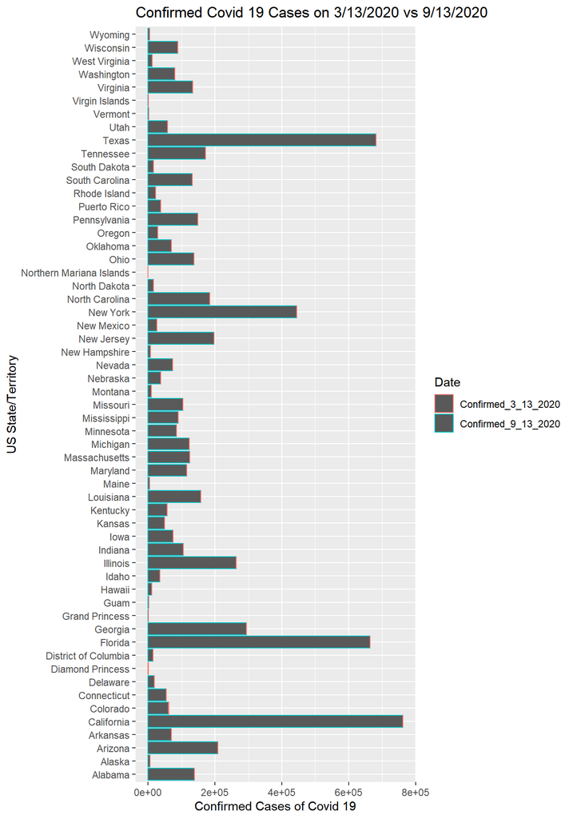

```r
ggplot(Confirmed_State_3_13_9_13_joined_long, aes(y = Confirmed,  x = Province_State))  +
    geom_bar(stat = "identity", aes(color = Date)) + coord_flip() + ylab("Confirmed Cases of Covid 19") + xlab("US State/Territory") + ggtitle("Confirmed Covid 19 Cases on 3/13/2020 vs 9/13/2020")
```

Just as a note, due to how small the numbers for 3/13 are in comparison 9/13, I have decided to keep the barplot stacked for the sake of visual clarity.

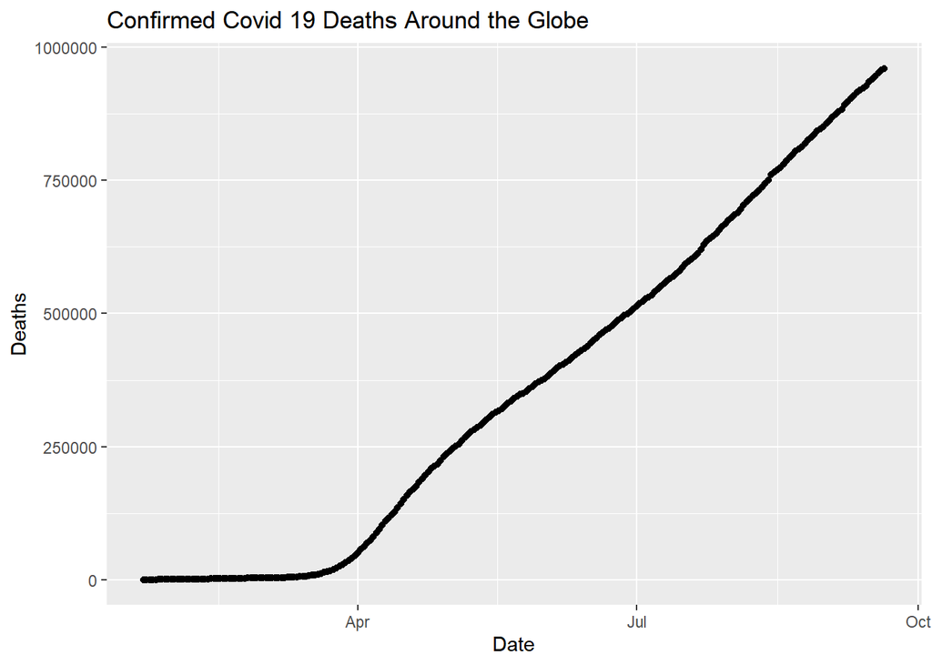

```r
time_series_long_joined %>%
    group_by(Date) %>%
    summarise_at(c("Confirmed", "Deaths"), sum) %>%
     ggplot(aes(x = Date,  y = Deaths)) +
      geom_point() +
      geom_line() +
      ggtitle("Confirmed Covid 19 Deaths Around the Globe")
```

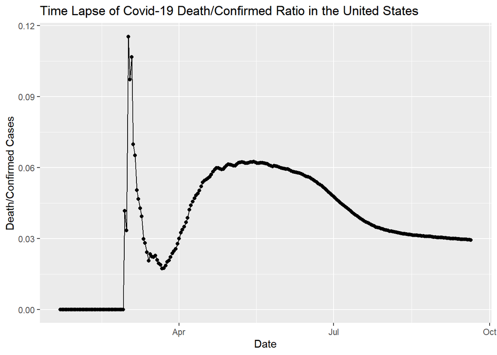

```r
t2 = time_series_long_joined %>%
  mutate(Deaths_to_Confirmed_ratio = Deaths/Confirmed )


t2 %>%
  filter (Country_Region == "US") %>%
  ggplot(aes(x = Date,  y = Deaths_to_Confirmed_ratio)) +
      geom_point() +
      geom_line() +
      ggtitle("Time Lapse of Covid-19 Death/Confirmed Ratio in the United States") + ylab("Death/Confirmed Cases")
```

```r
report_09_20_2020 <-   read_csv(url("https://raw.githubusercontent.com/CSSEGISandData/COVID-19/master/csse_covid_19_data/csse_covid_19_daily_reports/09-12-2020.csv"))
```

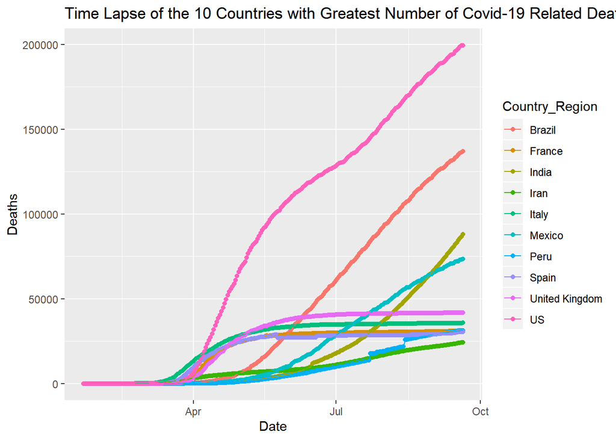

```r
 Top10deaths = report_09_20_2020 %>%
  group_by(Country_Region) %>%
  summarise(Deaths = sum(Deaths)) %>%
  arrange(desc(Deaths)) %>%
  select(Country_Region) %>%
  slice(0:10)

time_series_long_joined %>%
    group_by(Country_Region,Date) %>%
    summarise_at(c("Confirmed", "Deaths"), sum) %>%
    filter (Country_Region %in% Top10deaths$Country_Region) %>%
    ggplot(aes(x = Date,  y = Deaths, color = Country_Region)) +
    geom_point() +
    geom_line() +
    ggtitle("Time Lapse of the 10 Countries with Greatest Number of Covid-19 Related Deaths")
```

```r
library(ggthemes)
```

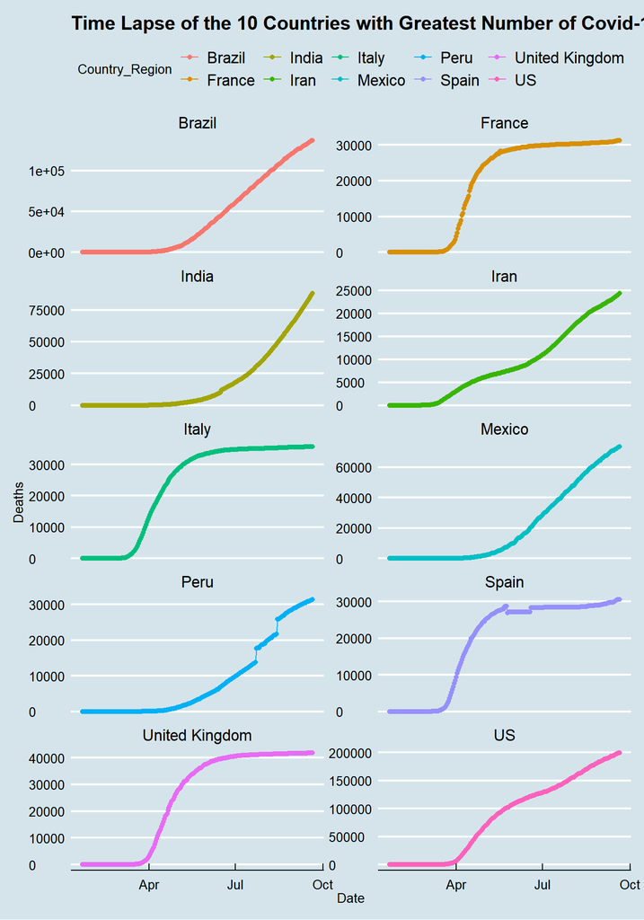

```r
time_series_long_joined %>%
    group_by(Country_Region,Date) %>%
    summarise_at(c("Confirmed", "Deaths"), sum) %>%
    filter (Country_Region %in% Top10deaths$Country_Region) %>%
    ggplot(aes(x = Date,  y = Deaths, color = Country_Region)) +
    geom_point() +
    geom_line() +
    ggtitle("Time Lapse of the 10 Countries with Greatest Number of Covid-19 Related Deaths") +
    facet_wrap(~Country_Region, ncol=2, scales="free_y") +
    theme_economist() + scale_fill_economist()
```

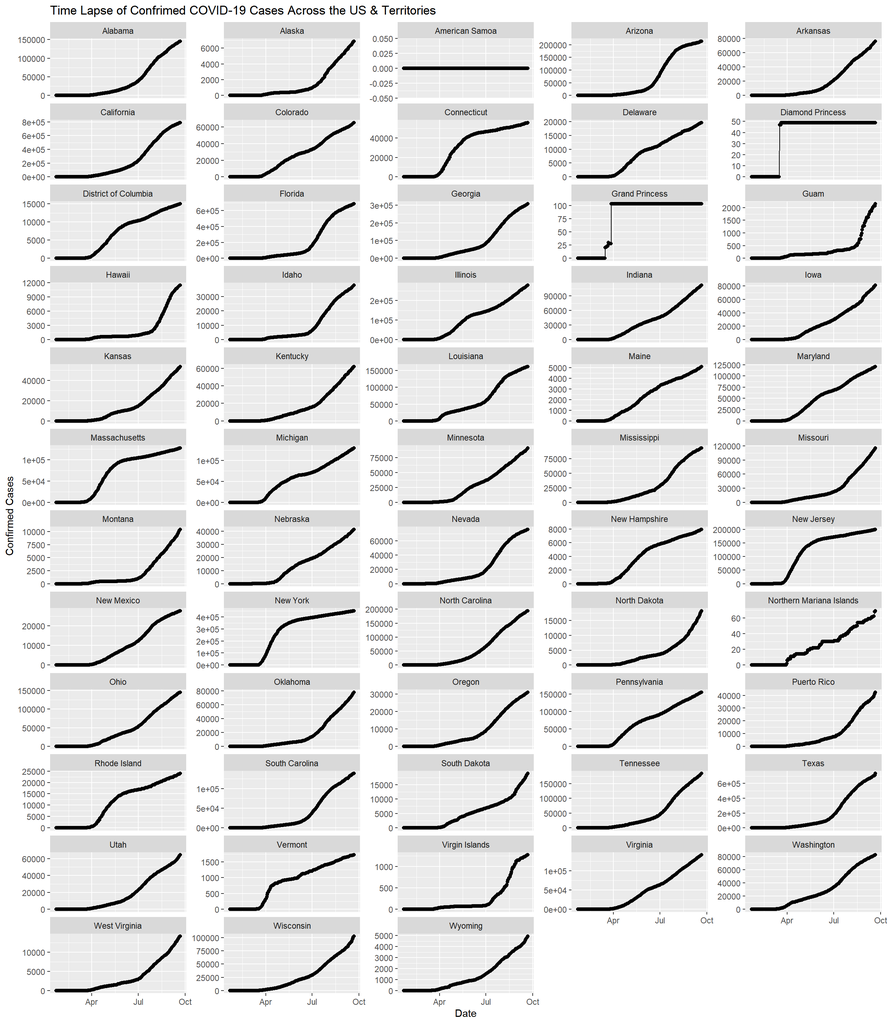

```r
time_series_confirmed_US = read_csv("data/time_series_covid19_confirmed_US.csv")

time_series_confirmed_US = time_series_confirmed_US %>%
               pivot_longer(-c(Province_State, Country_Region, UID, iso2, iso3, code3, FIPS, Admin2, Province_State, Country_Region, Lat, Long_, Combined_Key),
                            names_to = "Date", values_to = "Confirmed")
time_series_confirmed_US$Date = mdy(time_series_confirmed_US$Date)

time_series_confirmed_US %>%
  group_by(Province_State, Date) %>%
  summarise_at(c("Confirmed"), sum) %>%
  ggplot(aes(x = Date,  y = Confirmed)) +
    geom_point() +
    geom_line() +
    ggtitle("Time Lapse of Confrimed COVID-19 Cases Across the US & Territories") +
    facet_wrap(~Province_State, ncol=5, scales="free_y") + ylab("Confirmed Cases")
```